# Introduction to Econometrics with R

M. Arnold, M. Schmelzer, A. Gerber

2016-09-24

# Chapter 1: Prerequisites

In order to reproduce the examples in this script you need the statistical software package R. Additionally we recommend using the R editor software RStudio which will improve your R working experience.

### Installation of R and RStudio

Go to the following webpages and download the software adequate for your operating system:

1. **The Statistical Software Package R:** http://cran.r-project.org
2. **The GUI RStudio**: http://www.rstudio.com/products/rstudio/download/

Install R first and then procede with RStudio. Afterwards start RStudio.

### Working with RStudio

[figure not shown]

# Chapter 2

## Section 2.1

Since chapter reviews basic concepts of probability theory and how they can be applied in R.

The most common probability distributions are implemented in base R. That means that you can draw random numbers from these distributions, compute densities, probabilies or quantiles. …

# Chapter 3

## Section 3.5

### Table 3.1 - Not completed (sig. test)

```r
library(dplyr, quietly=T)
# Read in CPS data (taken from http:// ....)
cps_dat <- read.csv("data/cps_ch3.csv", sep=";", dec=".")
# Get an overview of the data structure
head(cps_dat)
```

```
##   a_sex year    ahe12
## 1     1 1992 18.30969
## 2     1 1992 16.36428
## 3     1 1992 24.47649
## 4     2 1992 14.17163
## 5     1 1992 23.60233
## 6     2 1992 12.98128
```

```r
# Take cps_dat %>% group data by gender and year %>% compute the mean, standard deviation
# and number of observations for each group
avgs <- cps_dat %>% group_by(a_sex, year) %>% summarise(mean(ahe12), sd(ahe12), n())
print(avgs, digits=2)
```

```
## Source: local data frame [12 x 5]
## Groups: a_sex [?]
##
##    a_sex  year `mean(ahe12)` `sd(ahe12)` `n()`
##    <int> <int>         <dbl>       <dbl> <int>
## 1      1  1992      24.83019   10.852310  1594
## 2      1  1996      23.97028   10.794585  1380
## 3      1  2000      26.54988   12.376707  1303
## 4      1  2004      26.80202   12.811654  1894
## 5      1  2008      26.63023   12.573526  1839
## 6      1  2012      25.29886   12.091118  2004
## 7      2  1992      21.38683    8.394597  1368
## 8      2  1996      20.25632    8.486105  1230
## 9      2  2000      22.12856    9.986240  1181
## 10     2  2004      22.42996    9.989347  1735
## 11     2  2008      22.26640   10.300938  1871
## 12     2  2012      21.50238    9.986548  1951
```

Now that we have the numbers we can compute the difference between both genders.

```r
male   <- avgs %>% filter(a_sex == 1)
female <- avgs %>% filter(a_sex == 2)
colnames(male)   <- c("Sex", "Year", "Y_bar_m", "s_m", "n_m")
colnames(female) <- c("Sex", "Year", "Y_bar_f", "s_f", "n_f")

# Gender gap, standard errors and confidence intervals
gap      <- male$Y_bar_m - female$Y_bar_f
gap_se   <- sqrt(male$s_m^2 / male$n_m + female$s_f^2 / female$n_f)
gap_ci_l <- gap - 1.96 * gap_se
gap_ci_u <- gap + 1.96 * gap_se
result <- cbind(male[,-1], female[,-(1:2)], gap, gap_se, gap_ci_l, gap_ci_u)
print(result, digits = 2)
```

```
##   Year Y_bar_m s_m  n_m Y_bar_f  s_f  n_f gap gap_se gap_ci_l gap_ci_u
## 1 1992      25  11 1594      21  8.4 1368 3.4   0.35      2.7      4.1
## 2 1996      24  11 1380      20  8.5 1230 3.7   0.38      3.0      4.5
## 3 2000      27  12 1303      22 10.0 1181 4.4   0.45      3.5      5.3
## 4 2004      27  13 1894      22 10.0 1735 4.4   0.38      3.6      5.1
## 5 2008      27  13 1839      22 10.3 1871 4.4   0.38      3.6      5.1
## 6 2012      25  12 2004      22 10.0 1951 3.8   0.35      3.1      4.5
```

# Chapter 4

## Linear Regression with One Regressor

This chapter introduces the simple linear regression model which relates one variable, $X$, to another variable $Y$. If for example a school cuts the class sizes by hiring new teachers, how would this effect the performance of the students? With linear regression we can not only examine whether the class size $\left(X\right)$ does have an impact on the test results $\left(Y\right)$. We can also learn something about the direction and the strength of this effect.

To start with an easy example consider the following combinations of average test scores and the average student to teacher ratios in some districts:

```r
class_data <- data.frame(TestScore           = c(680, 640, 670, 660, 630, 660, 635),
                         StudentTeacherRatio = c(15, 17, 19, 20, 22, 23.5, 25)
                         )
class_data
```

```
##   TestScore StudentTeacherRatio
## 1       680                15.0
## 2       640                17.0
## 3       670                19.0
## 4       660                20.0
## 5       630                22.0
## 6       660                23.5
## 7       635                25.0
```

If we use a simple linear regression model we assume that the relationship between the two variables can be represented by a straight line ($y = mx + n$). Lets suppose that the “true” function which relates test scores and student to teacher ratio is

$$TestScore = 713 - 3 \times ClassSize.$$

Now we use the `plot()` function to produce a scatterplot of the data from above. Furthermore, we add the line using the function `abline()`.

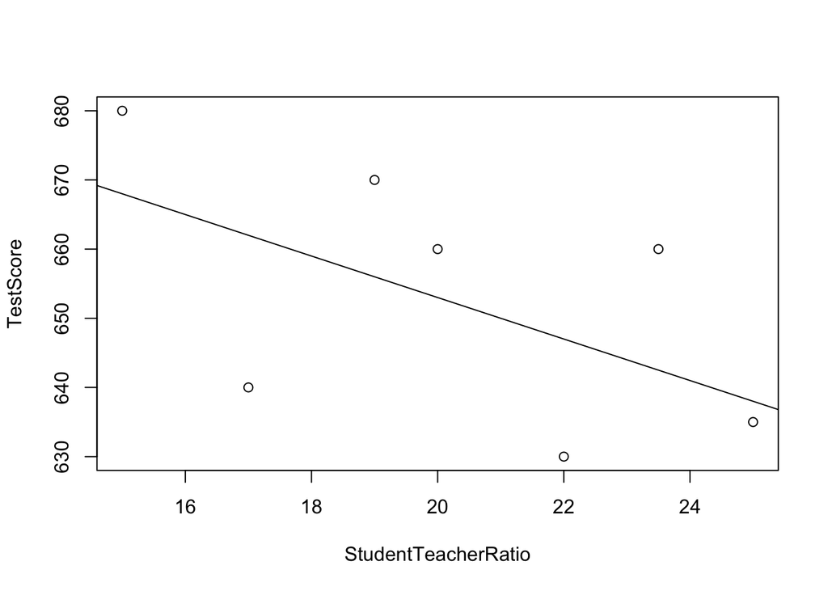

```r
plot(TestScore ~ StudentTeacherRatio, data = class_data)
abline(a = 713, b = -3)
```

We find that our line does not touch any of the points and still we argued that it represents the true relationship. The reason for this is the core problem of statistics, randomness. There are almost always effects which cannot be explained in a deterministic fashion and which excaberate the finding of the “truth”.

In order to account for the differences we extend the regression model by an **error term** which covers these random effect. In general the **error term** accounts for all differences between the “true” regression line and the actual observed data. This could next to the pure randomness also be measerment errors or the effect of important but not considered independent variables.

### Key Concept 4.1

### Terminology for the Linear Regression Model with a Single Regressor

The linear regression model is

$$Y_i = \beta_0 + \beta_1 X_1 + u_i$$

where

## 4.2 Estimating the Coefficients of the Linear Regression Model

In practical situations the intercept $\beta_0$ and slope $\beta_1$ of the population regression line are unknown. Therefore, we must use data to estimate the two unknown parameters. We will demonstrate how to do that on a real data example. We want to relate test scores to class sizes in 420 California school restricts. The test score is the districtwide average of reading and math scores for fifth graders. Class size is measured as the number of students divided by the number of teachers (student-teacher ratio). The California Shool dataset is available in the `AER` package. After installing the package with `install.packages("AER")` and attaching it with `library()` the dataset can be loaded using the `data()` function.

```r
library(AER)                                                    # contains the dataset
data(CASchools)
```

With `head()` we get a first overview over our data. This function shows only the first 6 rows of the dataset which prevents an overcrowded console output.

```r
head(CASchools)
```

```
##   district                          school  county grades students
## 1    75119              Sunol Glen Unified Alameda  KK-08      195
## 2    61499            Manzanita Elementary   Butte  KK-08      240
## 3    61549     Thermalito Union Elementary   Butte  KK-08     1550
## 4    61457 Golden Feather Union Elementary   Butte  KK-08      243
## 5    61523        Palermo Union Elementary   Butte  KK-08     1335
## 6    62042         Burrel Union Elementary  Fresno  KK-08      137
##   teachers calworks   lunch computer expenditure    income   english  read
## 1    10.90   0.5102  2.0408       67    6384.911 22.690001  0.000000 691.6
## 2    11.15  15.4167 47.9167      101    5099.381  9.824000  4.583333 660.5
## 3    82.90  55.0323 76.3226      169    5501.955  8.978000 30.000002 636.3
## 4    14.00  36.4754 77.0492       85    7101.831  8.978000  0.000000 651.9
## 5    71.50  33.1086 78.4270      171    5235.988  9.080333 13.857677 641.8
## 6     6.40  12.3188 86.9565       25    5580.147 10.415000 12.408759 605.7
##    math
## 1 690.0
## 2 661.9
## 3 650.9
## 4 643.5
## 5 639.9
## 6 605.4
```

We find that the dataset consists of plenty variables but the two we are intersted in (average test scores and student-teacher ratio) are not included. However, it is possible to calculate both from the existing data. To obtain the student to teacher-ratio we divide the number of students by the number of teachers. The avarage test score is the arithmetic mean of the test score for reading and the score of the math test.

```r
CASchools$tsratio  <- CASchools$students/CASchools$teachers     # teacher-student-ratio
CASchools$score    <- (CASchools$read + CASchools$math)/2       # average test-score
```

The next code chunk reproduces table 4.1 from the text book which summarizes the distribution of test scores and class sizes. In order to have a nice display format we gather all data after the computation in a data frame.

```r
avg_tsratio   <- mean(CASchools$tsratio)
avg_score     <- mean(CASchools$score)
sd_tsratio    <- sd(CASchools$tsratio)
sd_score      <- sd(CASchools$score)
quantiles     <- c(0.10, 0.25, 0.4, 0.5, 0.6, 0.75, 0.9)
quant_tsratio <- quantile(CASchools$tsratio, quantiles)
quant_score   <- quantile(CASchools$score, quantiles)

#Gather everything in a data frame
DistributionSummary <- data.frame(Average           = c(avg_tsratio, avg_score),
                                  StandardDeviation = c(sd_tsratio, sd_score),
                                  quantile          = rbind(quant_tsratio, quant_score)
                                  )
DistributionSummary
```

```
##                 Average StandardDeviation quantile.10. quantile.25.
## quant_tsratio  19.64043          1.891812      17.3486     18.58236
## quant_score   654.15655         19.053347     630.3950    640.05000
##               quantile.40. quantile.50. quantile.60. quantile.75.
## quant_tsratio     19.26618     19.72321      20.0783     20.87181
## quant_score      649.06999    654.45000     659.4000    666.66249
##               quantile.90.
## quant_tsratio     21.86741
## quant_score      678.85999
```

Before we start with the regression it is a good idea to take a closer look at our data set by plotting it. This allows us to detect specific characteristics of our data, such as outliers, which are hard to discover by looking at mere numbers. The easiest way to do so in `R` is the function `plot()`.  
Figure 4.2 shows a scatterplot of all observations. We see that the points are scatterd strongly and a apparent relationship cannot be detected with the naked eye.

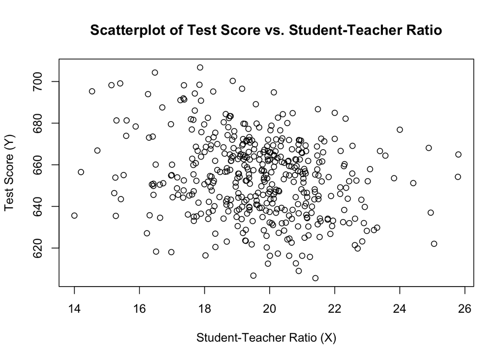

```r
plot(score ~ tsratio,
     data = CASchools,
     main = "Scatterplot of Test Score vs. Student-Teacher Ratio",
     xlab = "Student-Teacher Ratio (X)",
     ylab = "Test Score (Y)"
)
```

With the commad `cor()` the correlation between 2 variables can be computed. As the scatterplot already suggested the correlation is with $-0.23$ rather weak.

```r
cor(CASchools$tsratio, CASchools$score)
```

```
## [1] -0.2263627
```

The task we are facing now is to find the line which fits best to this data.